# Programacion Funcional

Práctica Guiada

```r
library(tidyverse)
library(openxlsx)
```

## Gráficos en serie

Veamos un ejemplo de aplicación de la programación funcional utilizando la base de datos `Gapminder` que viene en la librería homónima, que muestra algunos datos sobre la población de los países por año.

El objetivo de este ejercicio es hacer un gráfico por país de forma automática.

- Primero veamos los datos: La función `sample_n` nos permite tomar n cantidad de casos al azar.

```r
library(gapminder)
gapminder_unfiltered %>%
  sample_n(10)
```

| country | continent | year | lifeExp | pop | gdpPercap |
| --- | --- | --- | --- | --- | --- |
| Rwanda | Africa | 1957 | 41.500 | 2822082 | 540.2894 |
| Finland | Europe | 1985 | 74.440 | 4901783 | 19958.8137 |
| Czech Republic | Europe | 2000 | 75.060 | 10270128 | 16823.2378 |
| Bulgaria | Europe | 1966 | 71.230 | 8258057 | 5325.9534 |
| Costa Rica | Americas | 2007 | 78.782 | 4133884 | 9645.0614 |
| United Arab Emirates | Asia | 1987 | 71.339 | 1778365 | 29327.0588 |
| Guatemala | Americas | 1952 | 42.023 | 3146381 | 2428.2378 |
| Slovak Republic | Europe | 2001 | 73.610 | 5404681 | 13098.9114 |
| Sweden | Europe | 1970 | 74.700 | 8042803 | 17380.2559 |
| Cuba | Americas | 1967 | 68.290 | 8139332 | 5690.2680 |

la base tiene la siguiente info:

- country: Nombre del país
- continent: Nombre del continente
- year: año
- lifeExp: Esperanza de vida al nacer
- pop: Población
- gdpPercap: PBI per capita en dolares (ajustado por inflación)

Vamos a hacer un gráfico sencillo para Argentina

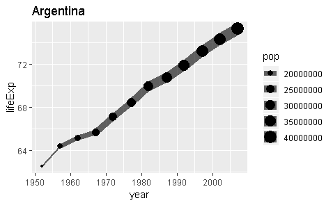

```r
options(scipen = 999)#Para que no muestre numeros en notación científica
data_argentina <- gapminder_unfiltered %>%
  filter(country=='Argentina')
ggplot(data_argentina, aes(year, lifeExp, size= pop))+
  geom_point()+
  geom_line(alpha=0.6)+
  labs(title = unique(data_argentina$country))
```

### Loop

Veamos como resolverlo vía la utilización de loops (aunque no es la práctica ideal en términos de tiempo de procesamiento).

1 - Nos quedamos con un vector que contenga los nombres de países

```r
paises <- unique(gapminder_unfiltered$country)
paises[1:10] # Veamos los primero 10 para ver si está ok
```

```
 [1] Afghanistan Albania     Algeria     Angola
 [5] Argentina   Armenia     Aruba       Australia
 [9] Austria     Azerbaijan
187 Levels: Afghanistan Albania Algeria Angola ... Zimbabwe
```

2 - Abrimos un dispositivo pdf en nuestra carpeta de resultados.

3 - Corremos un loop que iterativamente filtre la tabla para cada uno de los países y luego aplique el gráfico. (Lo acoto a los primeros 5 países porque tarda bastante)

```r
pdf('../Resultados/graficos_gapminder_loop.pdf')
for(i in paises[1:5]){


pais_i <-  gapminder_unfiltered %>%
  filter(country == i) ###PASO CLAVE: Filtro por país iterando


Graf_pais <- ggplot(pais_i, aes(year, lifeExp, size= pop))+
  geom_point()+
  geom_line(alpha=0.6)+
  labs(title = unique(pais_i$country))

print(Graf_pais)

}
dev.off()
```

### Función y Map

- Ahora veamos como hacer esto de la mejor forma posible.
- Diseñemos una función que tome como imputs un dataframe y un determinado pais, para entregar como output el gráfico en cuestión

```r
# definimos la función
graficar_pais <- function(data, pais){

  ggplot(data, aes(year, lifeExp, size= pop))+
    geom_point()+
    geom_line(alpha=0.6)+
    labs(title = pais)
}
```

probamos la función para un caso

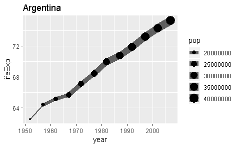

```r
graficar_pais(data_argentina, 'Argentina')
```

- Con la función `nest` nos armamos un dataset nesteado (en este caso implica que agrupe por país y guarde en otra variable un dataframe con todos los datos que le correspondan a ese país)

```r
gapminder_nest <- gapminder_unfiltered %>%
  group_by(country) %>%
  nest()
gapminder_nest
```

| country | data |
| --- | --- |
| Afghanistan |  |
| Albania |  |
| Algeria |  |
| Angola |  |
| Argentina |  |
| Armenia |  |
| Aruba |  |
| Australia |  |
| Austria |  |
| Azerbaijan |  |

[output cut: 177 more lines]

- Por ejemplo, dentro de nuestro objeto *gapminder_nest* el tibble de Afganistan contiene cada uno de los registros anuales de ese país
- Con este formato de datos, podemos crear una nueva columna que contenga los gráficos de cada país. Para ello utilizamos `map2` para pasarle a cada país nuestra función `graficar_pais`

```r
gapminder_nest <- gapminder_nest %>%
  mutate(grafico= map2(.x = data, .y = country,.f =  graficar_pais))
gapminder_nest
```

| country | data | grafico |
| --- | --- | --- |
| Afghanistan |  |  |
| Albania |  |  |
| Algeria |  |  |
| Angola |  |  |
| Argentina |  |  |
| Armenia |  |  |
| Aruba |  |  |
| Australia |  |  |
| Austria |  |  |
| Azerbaijan |  |  |

[output cut: 177 more lines]

- Ahora tenemos en nuestro objeto **gapminder_nest** una fila para cada país, donde en la variable *data* tenemos guardado todos sus datos anuales, y en la variable *grafico* tenemos guardado el grafico que le corresponde a ese país.
- Veamos un ejemplo

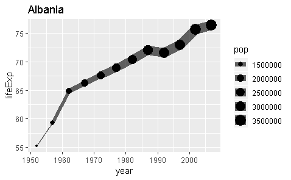

```r
gapminder_nest$grafico[2]
```

Ahora sin necesidad del loop podemos guardar todos los gráficos en un archivo PDF

```r
pdf('../Resultados/graficos_gapminder_map.pdf')
gapminder_nest$grafico
dev.off()
```